# Multivarible Regression - Week 3

## Multivariable regression analyses

- If I were to present evidence of a relationship between breath mint useage (mints per day, X) and pulmonary function (measured in FEV), you would be skeptical.
- Likely, you would say, ‘smokers tend to use more breath mints than non smokers, smoking is related to a loss in pulmonary function. That’s probably the culprit.’
- If asked what would convince you, you would likely say, ‘If non-smoking breath mint users had lower lung function than non-smoking non-breath mint users and, similarly, if smoking breath mint users had lower lung function than smoking non-breath mint users, I’d be more inclined to believe you’.
- In other words, to even consider my results, I would have to demonstrate that they hold while holding smoking status fixed.

## Multivariable regression analyses

- An insurance company is interested in how last year’s claims can predict a person’s time in the hospital this year.
- They want to use an enormous amount of data contained in claims to predict a single number. Simple linear regression is not equipped to handle more than one predictor.
- How can one generalize SLR to incoporate lots of regressors for the purpose of prediction?
- What are the consequences of adding lots of regressors?
- Surely there must be consequences to throwing variables in that aren’t related to Y?
- Surely there must be consequences to omitting variables that are?

## The linear model

- The general linear model extends simple linear regression (SLR) by adding terms linearly into the model.
  $$Y_i = \beta_1 X_{1i} + \beta_2 X_{2i} + \ldots +
  \beta_{p} X_{pi} + \epsilon_{i}
  = \sum_{k=1}^p X_{ik} \beta_j + \epsilon_{i}$$
- Here $X_{1i}=1$ typically, so that an intercept is included.
- Least squares (and hence ML estimates under iid Gaussianity of the errors) minimizes
  $$\sum_{i=1}^n \left(Y_i - \sum_{k=1}^p X_{ki} \beta_j\right)^2$$
- Note, the important linearity is linearity in the coefficients. Thus
  $$Y_i = \beta_1 X_{1i}^2 + \beta_2 X_{2i}^2 + \ldots +
  \beta_{p} X_{pi}^2 + \epsilon_{i}$$
  is still a linear model. (We’ve just squared the elements of the predictor variables.)

## How to get estimates

- Recall that the LS estimate for regression through the origin, $E[Y_i]=X_{1i}\beta_1$, was $\sum X_i Y_i / \sum X_i^2$.
- Let’s consider two regressors, $E[Y_i] = X_{1i}\beta_1 + X_{2i}\beta_2 = \mu_i$.
- Least squares tries to minimize
  $$\sum_{i=1}^n (Y_i - X_{1i} \beta_1 - X_{2i} \beta_2)^2$$

## Result

$$\hat \beta_1 = \frac{\sum_{i=1}^n e_{i, Y | X_2} e_{i, X_1 | X_2}}{\sum_{i=1}^n e_{i, X_1 | X_2}^2}$$
* That is, the regression estimate for $\beta_1$ is the regression through the origin estimate having regressed $X_2$ out of both the response and the predictor. * (Similarly, the regression estimate for $\beta_2$ is the regression through the origin estimate having regressed $X_1$ out of both the response and the predictor.) * More generally, multivariate regression estimates are exactly those having removed the linear relationship of the other variables from both the regressor and response.

## Example with two variables, simple linear regression

- $Y_{i} = \beta_1 X_{1i} + \beta_2 X_{2i}$ where $X_{2i} = 1$ is an intercept term.
- Notice the fitted coefficient of $X_{2i}$ on $Y_{i}$ is $\bar Y$
  - The residuals $e_{i, Y | X_2} = Y_i - \bar Y$
- Notice the fitted coefficient of $X_{2i}$ on $X_{1i}$ is $\bar X_1$
  - The residuals $e_{i, X_1 | X_2}= X_{1i} - \bar X_1$
- Thus
  $$\hat \beta_1 = \frac{\sum_{i=1}^n e_{i, Y | X_2} e_{i, X_1 | X_2}}{\sum_{i=1}^n e_{i, X_1 | X_2}^2} = \frac{\sum_{i=1}^n (X_i - \bar X)(Y_i - \bar Y)}{\sum_{i=1}^n (X_i - \bar X)^2}
  = Cor(X, Y) \frac{Sd(Y)}{Sd(X)}$$

## The general case

- Least squares solutions have to minimize
  $$\sum_{i=1}^n (Y_i - X_{1i}\beta_1 - \ldots - X_{pi}\beta_p)^2$$
- The least squares estimate for the coefficient of a multivariate regression model is exactly regression through the origin with the linear relationships with the other regressors removed from both the regressor and outcome by taking residuals.
- In this sense, multivariate regression “adjusts” a coefficient for the linear impact of the other variables.

## Demonstration that it works using an example

```r
n = 100; x = rnorm(n); x2 = rnorm(n); x3 = rnorm(n)
y = 1 + x + x2 + x3 + rnorm(n, sd = .1) # ciefficients are 1
ey = resid(lm(y ~ x2 + x3)) # residual for y
ex = resid(lm(x ~ x2 + x3)) # residual for x
sum(ey * ex) / sum(ex ^ 2) # regression through the origin estimate with the 2 residuals
```

```
[1] 0.9981384
```

```r
coef(lm(ey ~ ex - 1))
```

```
       ex
0.9981384
```

```r
coef(lm(y ~ x + x2 + x3)) # same coef as if regressing on this
```

```
(Intercept)           x          x2          x3
  1.0007927   0.9981384   0.9939707   0.9867567
```

## Interpretation of the coeficients

$$E[Y | X_1 = x_1, \ldots, X_p = x_p] = \sum_{k=1}^p x_{k} \beta_k$$

$$E[Y | X_1 = x_1 + 1, \ldots, X_p = x_p] = (x_1 + 1) \beta_1 + \sum_{k=2}^p x_{k} \beta_k$$

In the next lecture, we’ll do examples and go over context-specific interpretations.

## Fitted values, residuals and residual variation

All of our SLR quantities can be extended to linear models * Model $Y_i = \sum_{k=1}^p X_{ik} \beta_{k} + \epsilon_{i}$ where $\epsilon_i \sim N(0, \sigma^2)$ * Fitted responses $\hat Y_i = \sum_{k=1}^p X_{ik} \hat \beta_{k}$ * Residuals $e_i = Y_i - \hat Y_i$ * Variance estimate $\hat \sigma^2 = \frac{1}{n-p} \sum_{i=1}^n e_i ^2$ * To get predicted responses at new values, $x_1, \ldots, x_p$, simply plug them into the linear model $\sum_{k=1}^p x_{k} \hat \beta_{k}$ * Coefficients have standard errors, $\hat \sigma_{\hat \beta_k}$, and $\frac{\hat \beta_k - \beta_k}{\hat \sigma_{\hat \beta_k}}$ follows a $T$ distribution with $n-p$ degrees of freedom. * Predicted responses have standard errors and we can calculate predicted and expected response intervals.

## Linear models

- Linear models are the single most important applied statistical and machine learning techniqe, *by far*.
- Some amazing things that you can accomplish with linear models
- Decompose a signal into its harmonics.
- Flexibly fit complicated functions.
- Fit factor variables as predictors.
- Uncover complex multivariate relationships with the response.
- Build accurate prediction models.

## Data set for discussion

```r
data(swiss)
?swiss
```

Standardized fertility measure and socio-economic indicators for each of 47 French-speaking provinces of Switzerland at about 1888.

A data frame with 47 observations on 6 variables, each of which is in percent, i.e., in [0, 100].

- [,1] Fertility a common standardized fertility measure
- [,2] Agriculture % of males involved in agriculture as occupation
- [,3] Examination % draftees receiving highest mark on army examination
- [,4] Education % education beyond primary school for draftees
- [,5] Catholic % catholic (as opposed to protestant)
- [,6] Infant.Mortality live births who live less than 1 year

All variables but Fertility give proportions of the population.

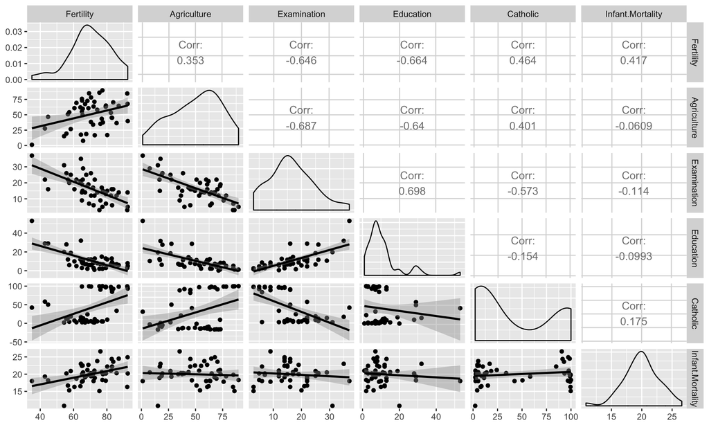

## Calling `lm`

`summary(lm(Fertility ~ . , data = swiss))`

```
                   Estimate  Std. Error   t value     Pr(>|t|)
(Intercept)      66.9151817 10.70603759  6.250229 1.906051e-07
Agriculture      -0.1721140  0.07030392 -2.448142 1.872715e-02
Examination      -0.2580082  0.25387820 -1.016268 3.154617e-01
Education        -0.8709401  0.18302860 -4.758492 2.430605e-05
Catholic          0.1041153  0.03525785  2.952969 5.190079e-03
Infant.Mortality  1.0770481  0.38171965  2.821568 7.335715e-03
```

## Example interpretation

- Agriculture is expressed in percentages (0 - 100)
- Estimate is -0.1721.
- Our models estimates an expected 0.17 decrease in standardized fertility for every 1% increase in percentage of males involved in agriculture in holding the remaining variables constant.
- The t-test for $H_0: \beta_{Agri} = 0$ versus $H_a: \beta_{Agri} \neq 0$ is significant.
- Interestingly, the unadjusted estimate is

```r
summary(lm(Fertility ~ Agriculture, data = swiss))$coefficients
```

```
              Estimate Std. Error   t value     Pr(>|t|)
(Intercept) 60.3043752 4.25125562 14.185074 3.216304e-18
Agriculture  0.1942017 0.07671176  2.531577 1.491720e-02
```

It changed sign!!

How can adjustment reverse the sign of an effect? Let’s try a simulation.

```r
n <- 100; x2 <- 1 : n
x1 <- .01 * x2 + runif(n, -.1, .1)
y = -x1 + x2 + rnorm(n, sd = .01)
summary(lm(y ~ x1))$coef
```

```
             Estimate Std. Error   t value     Pr(>|t|)
(Intercept)  1.515851   1.187340  1.276678 2.047330e-01
x1          95.251538   2.020884 47.133600 3.797129e-69
```

```r
summary(lm(y ~ x1 + x2))$coef
```

```
                 Estimate   Std. Error       t value      Pr(>|t|)
(Intercept) -0.0001771573 0.0019829148   -0.08934187  9.289944e-01
x1          -0.9774780655 0.0164447742  -59.44004171  4.125397e-78
x2           0.9997524202 0.0001672731 5976.76674644 8.883326e-272
```

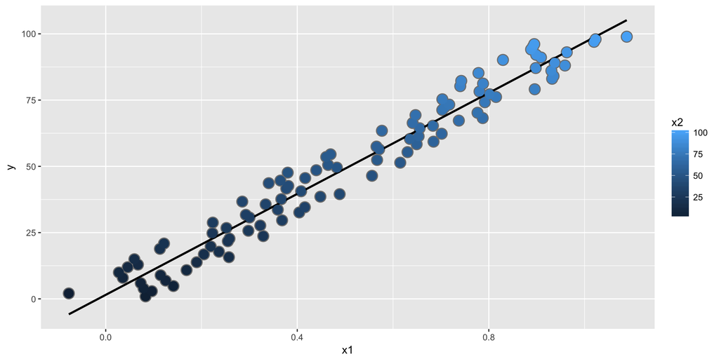

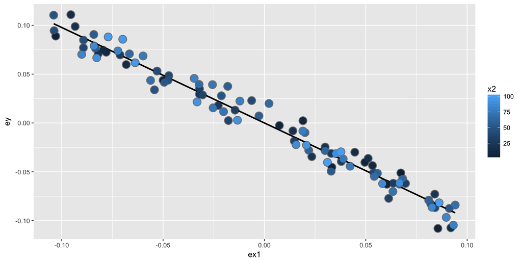

## Back to this data set

- The sign reverses itself with the inclusion of Examination and Education.
- The percent of males in the province working in agriculture is negatively related to educational attainment (correlation of -0.6395225) and Education and Examination (correlation of 0.6984153) are obviously measuring similar things.
- Is the positive marginal an artifact for not having accounted for, say, Education level? (Education does have a stronger effect, by the way.)
- At the minimum, anyone claiming that provinces that are more agricultural have higher fertility rates would immediately be open to criticism.

## What if we include an unnecessary variable?

z adds no new linear information, since it’s a linear combination of variables already included. R just drops terms that are linear combinations of other terms.

```r
z <- swiss$Agriculture + swiss$Education
lm(Fertility ~ . + z, data = swiss)
```

```
Call:
lm(formula = Fertility ~ . + z, data = swiss)

Coefficients:
     (Intercept)       Agriculture       Examination         Education          Catholic
         66.9152           -0.1721           -0.2580           -0.8709            0.1041
Infant.Mortality                 z
          1.0770                NA
```

## Dummy variables are smart

- Consider the linear model
  $$Y_i = \beta_0 + X_{i1} \beta_1 + \epsilon_{i}$$
  where each $X_{i1}$ is binary so that it is a 1 if measurement $i$ is in a group and 0 otherwise. (Treated versus not in a clinical trial, for example.)
- Then for people in the group $E[Y_i] = \beta_0 + \beta_1$
- And for people not in the group $E[Y_i] = \beta_0$
- The LS fits work out to be $\hat \beta_0 + \hat \beta_1$ is the mean for those in the group and $\hat \beta_0$ is the mean for those not in the group.
- $\beta_1$ is interpretted as the increase or decrease in the mean comparing those in the group to those not.
- Note including a binary variable that is 1 for those not in the group would be redundant. It would create three parameters to describe two means.

## More than 2 levels

- Consider a multilevel factor level. For didactic reasons, let’s say a three level factor (example, US political party affiliation: Republican, Democrat, Independent)
- $Y_i = \beta_0 + X_{i1} \beta_1 + X_{i2} \beta_2 + \epsilon_i$.
- $X_{i1}$ is 1 for Republicans and 0 otherwise.
- $X_{i2}$ is 1 for Democrats and 0 otherwise.
- If $i$ is Republican $E[Y_i] = \beta_0 +\beta_1$
- If $i$ is Democrat $E[Y_i] = \beta_0 + \beta_2$.
- If $i$ is Independent $E[Y_i] = \beta_0$.
- $\beta_1$ compares Republicans to Independents.
- $\beta_2$ compares Democrats to Independents.
- $\beta_1 - \beta_2$ compares Republicans to Democrats.
- (Choice of reference category changes the interpretation.)

## Insect Sprays

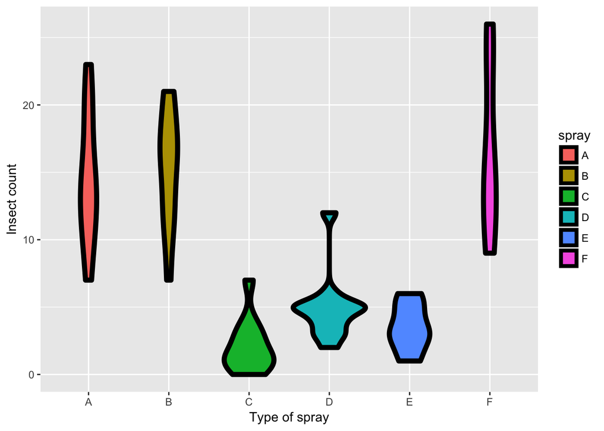

## Linear model fit, group A is the reference

```r
summary(lm(count ~ spray, data = InsectSprays))$coef
```

```
               Estimate Std. Error    t value     Pr(>|t|)
(Intercept)  14.5000000   1.132156 12.8074279 1.470512e-19
sprayB        0.8333333   1.601110  0.5204724 6.044761e-01
sprayC      -12.4166667   1.601110 -7.7550382 7.266893e-11
sprayD       -9.5833333   1.601110 -5.9854322 9.816910e-08
sprayE      -11.0000000   1.601110 -6.8702352 2.753922e-09
sprayF        2.1666667   1.601110  1.3532281 1.805998e-01
```

Everything presented above is in comparison with `sprayA`.

So `sprayB`, Estimate vaulue is 0.833. This is the change in the mean between `sprayB` and `sprayA`.

The `Intercept` 14.5 is the mean for `sprayA`.

The -12.41 is the difference between `sprayC` and `sprayA`.

Average count for `sprayB` would be 14.5 + 0.833

## Hard coding the dummy variables

```r
summary(lm(count ~
             I(1 * (spray == 'B')) + I(1 * (spray == 'C')) +
             I(1 * (spray == 'D')) + I(1 * (spray == 'E')) +
             I(1 * (spray == 'F'))
           , data = InsectSprays))$coef
```

```
                         Estimate Std. Error    t value     Pr(>|t|)
(Intercept)            14.5000000   1.132156 12.8074279 1.470512e-19
I(1 * (spray == "B"))   0.8333333   1.601110  0.5204724 6.044761e-01
I(1 * (spray == "C")) -12.4166667   1.601110 -7.7550382 7.266893e-11
I(1 * (spray == "D"))  -9.5833333   1.601110 -5.9854322 9.816910e-08
I(1 * (spray == "E")) -11.0000000   1.601110 -6.8702352 2.753922e-09
I(1 * (spray == "F"))   2.1666667   1.601110  1.3532281 1.805998e-01
```

## What if we include all 6?

```r
summary(lm(count ~
   I(1 * (spray == 'B')) + I(1 * (spray == 'C')) +
   I(1 * (spray == 'D')) + I(1 * (spray == 'E')) +
   I(1 * (spray == 'F')) + I(1 * (spray == 'A')), data = InsectSprays))$coef
```

```
                         Estimate Std. Error    t value     Pr(>|t|)
(Intercept)            14.5000000   1.132156 12.8074279 1.470512e-19
I(1 * (spray == "B"))   0.8333333   1.601110  0.5204724 6.044761e-01
I(1 * (spray == "C")) -12.4166667   1.601110 -7.7550382 7.266893e-11
I(1 * (spray == "D"))  -9.5833333   1.601110 -5.9854322 9.816910e-08
I(1 * (spray == "E")) -11.0000000   1.601110 -6.8702352 2.753922e-09
I(1 * (spray == "F"))   2.1666667   1.601110  1.3532281 1.805998e-01
```

## What if we omit the intercept?

```r
summary(lm(count ~ spray - 1, data = InsectSprays))$coef
```

```
        Estimate Std. Error   t value     Pr(>|t|)
sprayA 14.500000   1.132156 12.807428 1.470512e-19
sprayB 15.333333   1.132156 13.543487 1.001994e-20
sprayC  2.083333   1.132156  1.840148 7.024334e-02
sprayD  4.916667   1.132156  4.342749 4.953047e-05
sprayE  3.500000   1.132156  3.091448 2.916794e-03
sprayF 16.666667   1.132156 14.721181 1.573471e-22
```

```r
summarise(group_by(InsectSprays, spray), mn = mean(count))
```

```
# A tibble: 6 x 2
  spray     mn
  <fctr> <dbl>
1 A      14.5
2 B      15.3
3 C       2.08
4 D       4.92
5 E       3.50
6 F      16.7
```

## Reordering the levels

```r
spray2 <- relevel(InsectSprays$spray, "C")
summary(lm(count ~ spray2, data = InsectSprays))$coef
```

```
             Estimate Std. Error  t value     Pr(>|t|)
(Intercept)  2.083333   1.132156 1.840148 7.024334e-02
spray2A     12.416667   1.601110 7.755038 7.266893e-11
spray2B     13.250000   1.601110 8.275511 8.509776e-12
spray2D      2.833333   1.601110 1.769606 8.141205e-02
spray2E      1.416667   1.601110 0.884803 3.794750e-01
spray2F     14.583333   1.601110 9.108266 2.794343e-13
```

## Summary

- If we treat Spray as a factor, R includes an intercept and omits the alphabetically first level of the factor.
- All t-tests are for comparisons of Sprays versus Spray A.
- Emprirical mean for A is the intercept.
- Other group means are the itc plus their coefficient.
- If we omit an intercept, then it includes terms for all levels of the factor.
- Group means are the coefficients.
- Tests are tests of whether the groups are different than zero. (Are the expected counts zero for that spray.)
- If we want comparisons between, Spray B and C, say we could refit the model with C (or B) as the reference level.

## Other thoughts on this data

- Counts are bounded from below by 0, violates the assumption of normality of the errors.
- Also there are counts near zero, so both the actual assumption and the intent of the assumption are violated.
- Variance does not appear to be constant.
- Perhaps taking logs of the counts would help.
- There are 0 counts, so maybe log(Count + 1)
- Also, we’ll cover Poisson GLMs for fitting count data.

## Recall the `swiss` data set

```r
data(swiss)
head(swiss)
```

```
             Fertility Agriculture Examination Education Catholic Infant.Mortality
Courtelary        80.2        17.0          15        12     9.96             22.2
Delemont          83.1        45.1           6         9    84.84             22.2
Franches-Mnt      92.5        39.7           5         5    93.40             20.2
Moutier           85.8        36.5          12         7    33.77             20.3
Neuveville        76.9        43.5          17        15     5.16             20.6
Porrentruy        76.1        35.3           9         7    90.57             26.6
```

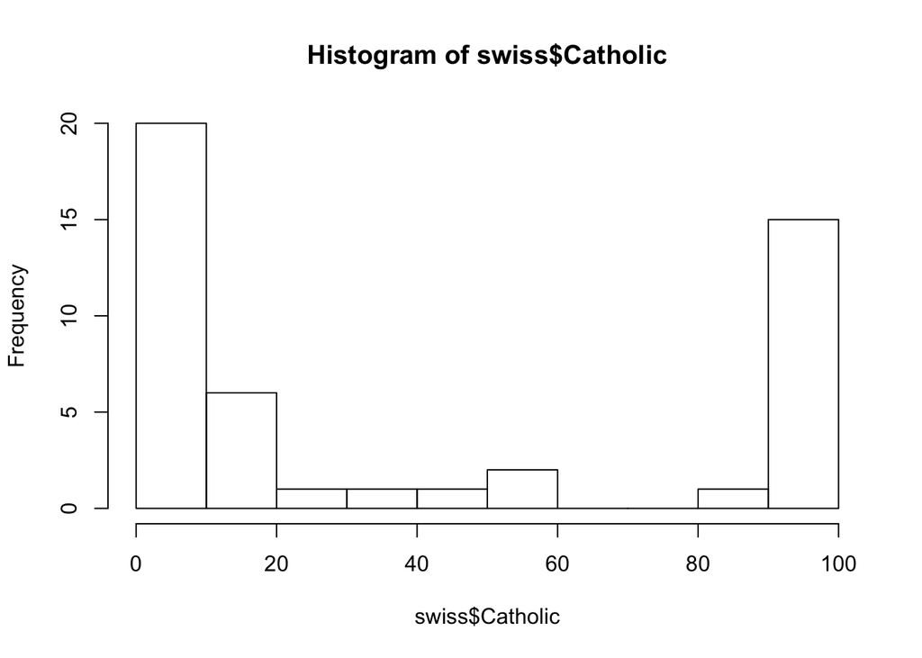

```r
hist(swiss$Catholic)
```

## Create a binary variable

```r
swiss = mutate(swiss, CatholicBin = 1 * (Catholic > 50))
```

## Plot the data

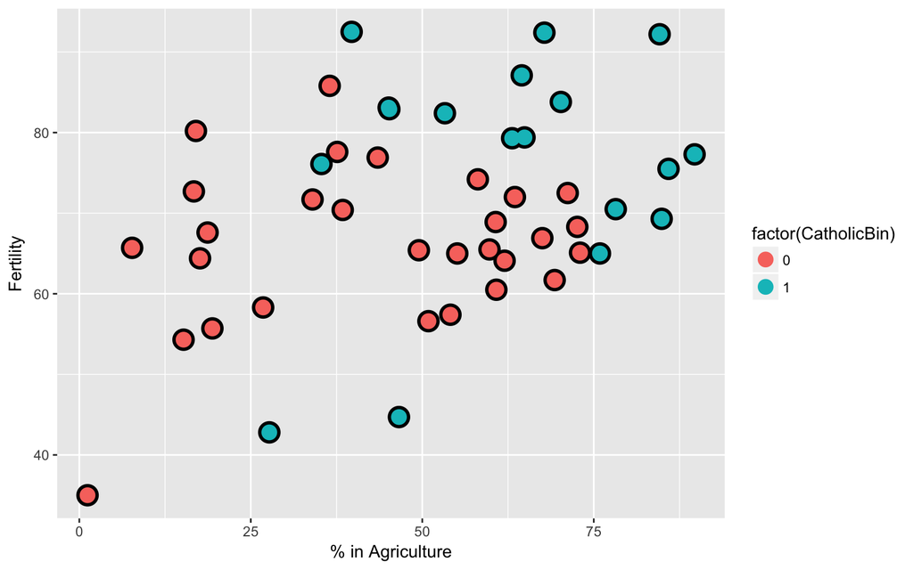

## No effect of religion

```r
summary(lm(Fertility ~ Agriculture, data = swiss))$coef
```

```
              Estimate Std. Error   t value     Pr(>|t|)
(Intercept) 60.3043752 4.25125562 14.185074 3.216304e-18
Agriculture  0.1942017 0.07671176  2.531577 1.491720e-02
```

## The associated fitted line

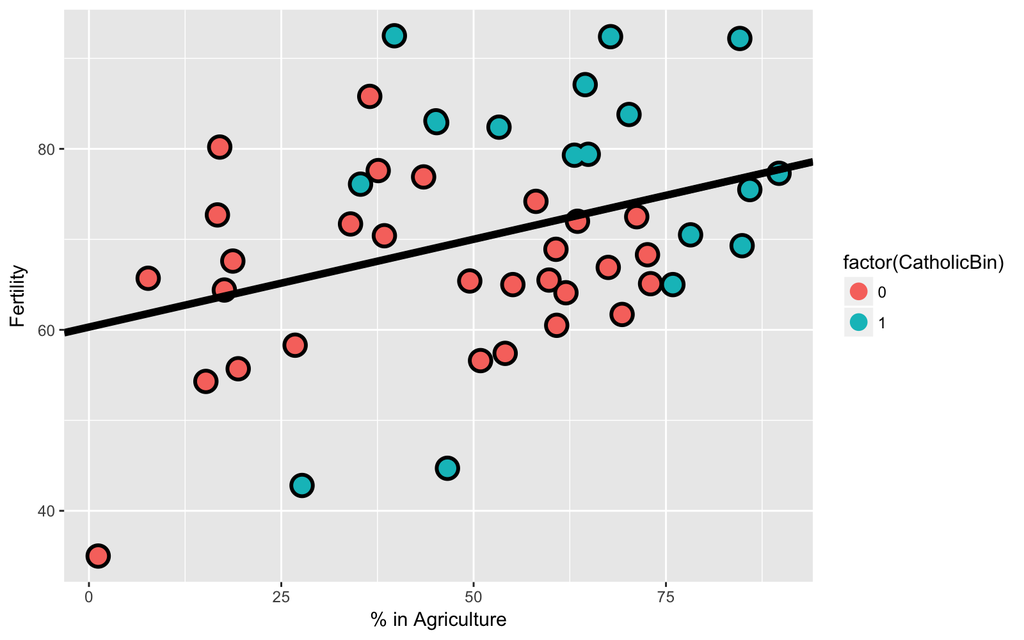

## Parallel lines

```r
summary(lm(Fertility ~ Agriculture + factor(CatholicBin), data = swiss))$coef
```

```
                       Estimate Std. Error   t value     Pr(>|t|)
(Intercept)          60.8322366  4.1058630 14.815944 1.032493e-18
Agriculture           0.1241776  0.0810977  1.531210 1.328763e-01
factor(CatholicBin)1  7.8843292  3.7483622  2.103406 4.118221e-02
```

## Fitted lines

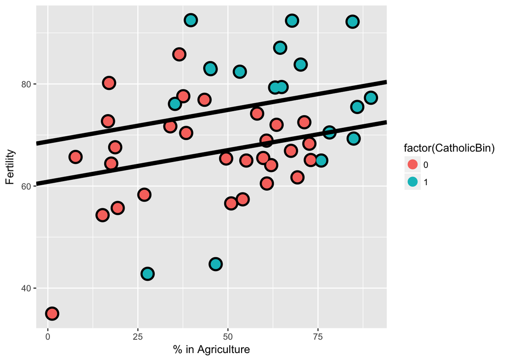

## Lines with different slopes and intercepts

```r
summary(lm(Fertility ~ Agriculture * factor(CatholicBin), data = swiss))$coef
```

```
                                    Estimate  Std. Error    t value     Pr(>|t|)
(Intercept)                      62.04993019  4.78915566 12.9563402 1.919379e-16
Agriculture                       0.09611572  0.09881204  0.9727127 3.361364e-01
factor(CatholicBin)1              2.85770359 10.62644275  0.2689238 7.892745e-01
Agriculture:factor(CatholicBin)1  0.08913512  0.17610660  0.5061430 6.153416e-01
```

## Fitted lines

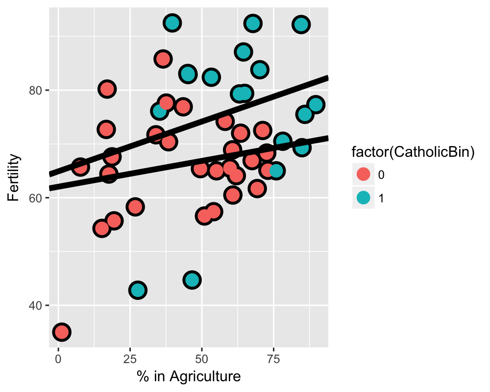

## Just to show you it can be done

```r
summary(lm(Fertility ~ Agriculture + Agriculture : factor(CatholicBin), data = swiss))$coef
```

```
                                    Estimate Std. Error    t value     Pr(>|t|)
(Intercept)                      62.63037278 4.22989475 14.8066031 1.056741e-18
Agriculture                       0.08539357 0.08945287  0.9546209 3.449849e-01
Agriculture:factor(CatholicBin)1  0.13339603 0.06198753  2.1519817 3.692561e-02
```

## Exercises

1. Load the dataset Seatbelts as part of the datasets package via data(Seatbelts). Use as.data.frame to convert the object to a dataframe. Fit a linear model of driver deaths with kms and PetrolPrice as predictors. Interpret your results.

```
  DriversKilled drivers front rear   kms PetrolPrice VanKilled law
1           107    1687   867  269  9059   0.1029718        12   0
2            97    1508   825  265  7685   0.1023630         6   0
3           102    1507   806  319  9963   0.1020625        12   0
4            87    1385   814  407 10955   0.1008733         8   0
5           119    1632   991  454 11823   0.1010197        10   0
6           106    1511   945  427 12391   0.1005812        13   0
```

```
             Estimate Std. Error t value Pr(>|t|)
(Intercept)  215.7461    14.6656 14.7110   0.0000
kms           -0.0017     0.0006 -2.8469   0.0049
PetrolPrice -643.7895   148.2896 -4.3414   0.0000
```

```
              Estimate Std. Error   t value      Pr(>|t|)
(Intercept) 122.802083  1.6628507 73.850336 2.395106e-141
mmc          -1.749546  0.6145401 -2.846919  4.902428e-03
pp           -7.838674  1.8055491 -4.341435  2.304713e-05
```

```
The intercept  122.8021  is the estimated number of drivers killed for the average petrol price and the average distance driven.
The petrol price, -7.838674  means an estimate of  7.84 fewer deaths per i sd change in petrol proce.
The  -1.749546  means around 1.75 fewer deths per every thousand km driven.
```

2. Predict the number of driver deaths at the average kms and petrol levels.

```r
fit = lm(DriversKilled ~ kms + PetrolPrice, data = seatbelts)
predict(fit, newdata = data.frame(kms = mean(seatbelts$kms),
                                  PetrolPrice = mean(seatbelts$PetrolPrice)))
```

```
       1
122.8021
```

3. Take the residual for DriversKilled having regressed out kms and an intercept and the residual for PetrolPrice having regressed out kms and an intercept. Fit a regression through the origin of the two residuals and show that it is the same as your coefficient obtained in question 1.

```
   Min. 1st Qu.  Median    Mean 3rd Qu.    Max.
   60.0   104.8   118.5   122.8   138.0   198.0
```

```
     Estimate Std. Error   t value     Pr(>|t|)
epp -643.7895   147.5111 -4.364345 2.085664e-05
```

```
                 Estimate   Std. Error   t value     Pr(>|t|)
(Intercept)  2.157461e+02 1.466559e+01 14.711047 3.772201e-33
kms         -1.749546e-03 6.145401e-04 -2.846919 4.902428e-03
pp          -6.437895e+02 1.482896e+02 -4.341435 2.304713e-05
```

4. Load the dataset Seatbelts as part of the datasets package via data(Seatbelts). Use as.data.frame to convert the object to a dataframe. Fit a linear model of driver deaths with kms and PetrolPrice as predictors. Interpret your results.

```
  DriversKilled drivers front rear   kms PetrolPrice VanKilled law
1           107    1687   867  269  9059   0.1029718        12   0
2            97    1508   825  265  7685   0.1023630         6   0
3           102    1507   806  319  9963   0.1020625        12   0
4            87    1385   814  407 10955   0.1008733         8   0
5           119    1632   991  454 11823   0.1010197        10   0
6           106    1511   945  427 12391   0.1005812        13   0
```

```
             Estimate Std. Error t value Pr(>|t|)
(Intercept)  215.7461    14.6656 14.7110   0.0000
kms           -0.0017     0.0006 -2.8469   0.0049
PetrolPrice -643.7895   148.2896 -4.3414   0.0000
```

```
              Estimate Std. Error   t value      Pr(>|t|)
(Intercept) 122.802083  1.6628507 73.850336 2.395106e-141
mmc          -1.749546  0.6145401 -2.846919  4.902428e-03
pp           -7.838674  1.8055491 -4.341435  2.304713e-05
```

```
The intercept  122.8021  is the estimated number of drivers killed for the average petrol price and the average distance driven.
The petrol price, -7.838674  means an estimate of  7.84 fewer deaths per i sd change in petrol proce.
The  -1.749546  means around 1.75 fewer deths per every thousand km driven.
```

5. Repeat question 4 for the outcome being the log of the count of driver deaths. Interpret your coefficients.

```
               Estimate  Std. Error    t value      Pr(>|t|)
(Intercept)  4.78966306 0.013426810 356.723817 2.737888e-269
mmc         -0.01400794 0.004962149  -2.822959  5.267843e-03
pp          -0.06412578 0.014579039  -4.398492  1.818005e-05
```

```
The normalized petrol price variable is  6.211298 . Which means a,  6.211298 % decrease in the geometrical mean of dirvers killed for every 1 sd increase in normalized petrol price, holding KM constant.
```

```r
seatbelts = mutate(seatbelts,
                   pp = (PetrolPrice - mean(PetrolPrice)) / sd(PetrolPrice), # normalized petrol price
                   mm = kms / 1000, # mega meter
                   mmc = mm - mean(mm)) # center mm

fit = lm(DriversKilled ~ pp + mmc + law, data = seatbelts)
summary(fit)
```

```
Call:
lm(formula = DriversKilled ~ pp + mmc + law, data = seatbelts)

Residuals:
   Min     1Q Median     3Q    Max
-50.69 -17.29  -4.05  14.33  60.71

Coefficients:
            Estimate Std. Error t value Pr(>|t|)
(Intercept) 124.2263     1.8012  68.967  < 2e-16 ***
pp           -6.9199     1.8514  -3.738 0.000246 ***
mmc          -1.2233     0.6657  -1.838 0.067676 .
law         -11.8892     6.0258  -1.973 0.049955 *
---
Signif. codes:  0 '***' 0.001 '**' 0.01 '*' 0.05 '.' 0.1 ' ' 1

Residual standard error: 22.87 on 188 degrees of freedom
Multiple R-squared:  0.201, Adjusted R-squared:  0.1882
F-statistic: 15.76 on 3 and 188 DF,  p-value: 3.478e-09
```

```r
# would be the same as
# fit = lm(DriversKilled ~ pp + mmc + I(factor(law)), data = seatbelts)
# summary(fit)
```

7. Discretize the PetrolPrice variable into four factor levels. Fit the linear model with this factor to see how R treats multiple level factor variables.

```r
seatbelts = mutate(seatbelts,
                   pp = (PetrolPrice - mean(PetrolPrice)) / sd(PetrolPrice), # normalized petrol price
                   ppfactor = as.factor((pp <= -1.5) + (pp <= 0) + (pp < 1.5) + (pp < Inf)),
                   mm = kms / 1000, # mega meter
                   mmc = mm - mean(mm)) # center mm

fit = lm(DriversKilled ~ ppfactor + mmc + law, data = seatbelts)
summary(fit)$coef
```

```
              Estimate Std. Error   t value     Pr(>|t|)
(Intercept) 109.840450  9.5066206 11.554101 1.265314e-23
ppfactor2    10.827094  9.9462097  1.088565 2.777543e-01
ppfactor3    18.690363  9.9374155  1.880807 6.156089e-02
ppfactor4    25.007367 10.9163090  2.290826 2.309488e-02
mmc          -1.299125  0.7667899 -1.694239 9.189369e-02
law         -15.344487  6.0345096 -2.542789 1.181168e-02
```